# Exercise #2: Quantification

# Bulk RNA-seq Quantification

In this tutorial, we look at the results of bulk RNA-seq quantification. Our data comes from the [following paper](https://pmc.ncbi.nlm.nih.gov/articles/PMC9674345/).

It is not important to understand the paper in detail. Just know we are dealing with two colon cancer cell-lines “HCT116” and “SW480” which have been FACS-sorted according to the expression of CD44 and EpCAM, “EpCAMhigh” and “EpCAMlow”, resulting in 4 groups with 4 replicates each.

- HCT116: EpCAMhigh
- HCT116: EpCAMlow
- SW480: EpCAMhigh
- SW480: EpCAMlow

We will focus on the tools available for QC rather than the underlying biology.

## Setup

### Load required packages

```r
suppressPackageStartupMessages({
  library(SummarizedExperiment)
  library(pheatmap)
  library(RColorBrewer)
  library(stringr)
  library(plotly)
  library(tidyverse)
})
```

### Downloading counts

First, let’s fetch the input count files generated from featureCounts for each sample.

```r
ftpLocation <- "https://fgcz-gstore.uzh.ch/public/OmicsInOncology_CPS341nBio435_FS25_week3/feature_counts"
countDirectoryToUse <- "feature_counts"
dir.create(countDirectoryToUse, showWarnings = FALSE)

sampleNames <- c(
  "HCT116_EpCAMhigh_1",
  "HCT116_EpCAMhigh_2",
  "HCT116_EpCAMhigh_3",
  "HCT116_EpCAMhigh_4",
  "HCT116_EpCAMlow_1",
  "HCT116_EpCAMlow_2",
  "HCT116_EpCAMlow_3",
  "HCT116_EpCAMlow_4",
  "SW480_EpCAMhigh_1",
  "SW480_EpCAMhigh_2",
  "SW480_EpCAMhigh_3",
  "SW480_EpCAMhigh_4",
  "SW480_EpCAMlow_1",
  "SW480_EpCAMlow_2",
  "SW480_EpCAMlow_3",
  "SW480_EpCAMlow_4"
)

countFilenames <- paste0(sampleNames, ".txt")

for (fn in countFilenames) {
  download.file(url=file.path(ftpLocation, fn),
                destfile=file.path(countDirectoryToUse, fn))
}
```

You will notice a new directory called “feature_counts” in the same folder where you executed this code. Take a quick look inside.

How were these counts generated?

- Trimming with `fastp`
- Alignment with `STAR` to the GRCh38.p13 reference genome
- Running featureCounts from the Rsubread package using the GENCODE Release 42 GTF file. The file used can be found here on our [public FTP](https://fgcz-gstore.uzh.ch/public/OmicsInOncology_CPS341nBio435_FS25_week3)

The file is quite large and you need not be familiar with its format at this point or download it. What is important to know is that this file has been subset to only the protein_coding genes.

There are a few reasons why we might rather exclude transcript types such as lncRNA and snRNA.

- Including these other transcript types increase the number of tests, meaning more false positives, and less power to detect protein-coding genes
- non-coding RNAs do not have poly-A tails and can’t be detected with mRNA sequencing, so their absence might be misinterpreted
- They are sometimes not well annotated and this can adversely affect enrichment analysis

In general, a good strategy is to exclude them by default and include them by demand (i.e. if the research question explicitly demands it).

### Loading counts

Now that the we have generated the counts, we can start exploring the data. We could proceed with either the counts generated by Kallisto or featureCounts. Let’s load the featureCounts for now.

```r
# Define meta dataframe for later use
meta <- data.frame(
  Condition=as.factor(c(rep("HCT116_EpCAMhigh", 4),
                        rep("HCT116_EpCAMlow", 4),
                        rep("SW480_EpCAMhigh", 4),
                        rep("SW480_EpCAMlow", 4))),
  row.names=sampleNames
)

# Define some general-use parameters for use later
sigThresh <- 10  # significane threshold for the counts
conditionColours <- scales::hue_pal()(length(unique(meta$Condition)))  # choose pretty colours
# associate the conditions with the pretty colours
names(conditionColours) <- unique(meta$Condition)
sampleColours <- conditionColours[meta$Condition]
```

First, we load the counts and combine them into a single data-frame. Note we do this here manually, but there are methods like the `tximport` function which perform this operation in a convenient way, and beyond this, correct for biases in the counts. We will be using this method of import in the optional section on differential expression analysis.

```r
# Find the count files on the system
countPaths <- Sys.glob(file.path(countDirectoryToUse, sprintf("*%s.txt", rownames(meta))))
names(countPaths) <- rownames(meta)

# Load into memory and combine
countList <- lapply(rownames(meta), function(sn) {
  count <- data.table::fread(countPaths[[sn]]) %>%
    as.data.frame() %>%
    column_to_rownames(var="Identifier") %>%
    dplyr::rename_with(~sn)
  return(count)
})
rawCounts <- bind_cols(countList)

# Save merged data for later use
saveRDS(rawCounts, file=file.path(countDirectoryToUse, "mergedCounts.rds"))
```

## Count Statistics

Let’s look at the count statistics first. In the first of two plots, we get the total counts for each sample. In the second, we see how many features, and what fraction of all features, exceed our signal threshold.

```r
toPlot <- tibble(
  Sample=colnames(rawCounts),
  `Read Counts`=colSums(rawCounts),
  `Fraction of features above threshold`=colSums(rawCounts > sigThresh),
  Percentages=paste(signif(100 * colSums(rawCounts > sigThresh) / nrow(rawCounts), digits=2), "%")
)
plot_ly(toPlot, x = ~Sample, y = ~`Read Counts`, type = "bar") %>%
  layout(title="Total reads", yaxis = list(title = "Counts [Mio]"))
```

[interactive chart not shown]

```r
plot_ly(toPlot, x = ~Sample, y = ~`Fraction of features above threshold`, type="bar",
        text=~Percentages, textposition = 'auto') %>%
  layout(title="Genomic features with reads above threshold", yaxis = list(title = "Count"))
```

[interactive chart not shown]

### Exercise #2

1. How do the read counts compare to the initial FastQC report? See the plot below.

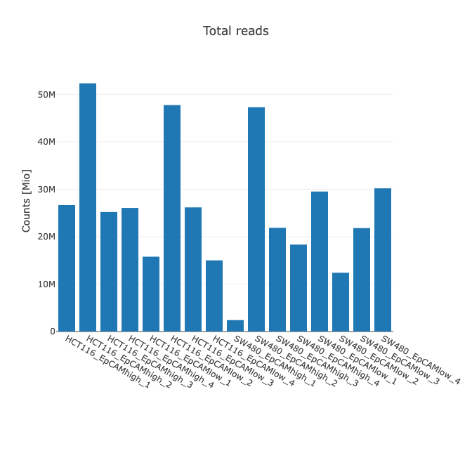

Raw fastq read counts for each sample

2. How many features (in %) are above threshold? Do you think re-sequencing the samples with relatively low counts will be useful or provide a significant return on investment?

**Solutions**

1. The counts after mapping and quantification are lower.
2. All around 50-60%. Re-sequencing is unlikely to be worth our time, unless we are interested in very lowly-expressed genes. Even the sample with the lowest counts has almost as a considerable number of features with a count above, despite having only a fraction of the counts.

## Filtering Counts

Before continuing, we should filter out genes which are lowly expressed or absent, which we do this on a per-group basis (think about why this might be). Next, we generate normalised counts using “Variance Stabilisation” as provided in the DESeq2 package. As per the documentation, this function calculates a variance stabilizing transformation (VST) from the fitted dispersion-mean relation(s) and then transforms the count data (normalized by division by the size factors or normalization factors), yielding a matrix of values which now have constant variance along the range of mean values (homoskedastic)(Love, Huber, and Anders 2014). There are other functions we could use, such as `rlog` which is less sensitive to size factors, but VST works well in the general case.

```r
# First filter genes which are at expressed below threshold in less than half the samples within a group
isPresent <- rawCounts > sigThresh
isPresentCond <- rowsum(t(isPresent * 1), group=meta$Condition)
isPresentCond <- t(sweep(isPresentCond, 1,
                         table(meta$Condition)[rownames(isPresentCond)], FUN="/")) >= 0.5
isValid <- rowMeans(isPresentCond) >= 0.5
rawCountsFilt <- rawCounts[isValid, ]

# Load data into a DESeq2 dataset so we can use the variance stabilizing function from Deseq2
dds <- DESeq2::DESeqDataSetFromMatrix(countData=rawCountsFilt,
                                      colData=meta,
                                      design=~Condition)
vsd <- DESeq2::vst(dds)

# Extract normalized counts
vsdSE <- SummarizedExperiment::assay(vsd)
```

Let’s quickly compare the raw and normalised counts to see how they have changed.

```r
head(rawCountsFilt)
```

```
                HCT116_EpCAMhigh_1 HCT116_EpCAMhigh_2 HCT116_EpCAMhigh_3
ENSG00000187634                290                505                253
ENSG00000188976               8568              16492               9221
ENSG00000187961               1025               1914                871
ENSG00000187583                148                326                181
ENSG00000187642                 22                 58                 27
ENSG00000188290                103                196                116
                HCT116_EpCAMhigh_4 HCT116_EpCAMlow_1 HCT116_EpCAMlow_2
ENSG00000187634                252               125               371
ENSG00000188976               7034              3262              9800
ENSG00000187961               1052               360              1536
ENSG00000187583                148                54               234
ENSG00000187642                 20                 7                51
ENSG00000188290                122                45               194
                HCT116_EpCAMlow_3 HCT116_EpCAMlow_4 SW480_EpCAMhigh_1
ENSG00000187634               185               101                 5
ENSG00000188976              6339              2471               228
ENSG00000187961               870               304                12
ENSG00000187583               145                44                 8
ENSG00000187642                23                 7                 1
ENSG00000188290                94                29                 3
                SW480_EpCAMhigh_2 SW480_EpCAMhigh_3 SW480_EpCAMhigh_4
ENSG00000187634               163                92                62
ENSG00000188976              6415              3448              3318
ENSG00000187961               300               205               170
ENSG00000187583               227               153               115
ENSG00000187642                22                18                15
ENSG00000188290                62                20                30
                SW480_EpCAMlow_1 SW480_EpCAMlow_2 SW480_EpCAMlow_3
ENSG00000187634               74               26               73
ENSG00000188976             3243             1124             2175
ENSG00000187961              204               63               99
ENSG00000187583               65               29               22
ENSG00000187642                5                2                2
ENSG00000188290               21                4                7
                SW480_EpCAMlow_4
ENSG00000187634               73
ENSG00000188976             2698
ENSG00000187961              149
ENSG00000187583               28
ENSG00000187642                3
ENSG00000188290               11
```

```r
head(as.data.frame(vsdSE))
```

```
                HCT116_EpCAMhigh_1 HCT116_EpCAMhigh_2 HCT116_EpCAMhigh_3
ENSG00000187634           8.672862           8.578033           8.651217
ENSG00000188976          12.768795          12.752728          13.028374
ENSG00000187961           9.972398           9.923392           9.912150
ENSG00000187583           8.153481           8.239491           8.379435
ENSG00000187642           7.266120           7.361191           7.365607
ENSG00000188290           7.923728           7.910310           8.065749
                HCT116_EpCAMhigh_4 HCT116_EpCAMlow_1 HCT116_EpCAMlow_2
ENSG00000187634           8.590065          8.460559          8.411885
ENSG00000188976          12.553433         12.239514         12.170682
ENSG00000187961          10.054280          9.452903          9.787046
ENSG00000187583           8.183144          7.888802          8.082709
ENSG00000187642           7.251120          7.123178          7.352301
ENSG00000188290           8.054338          7.788190          7.964821
                HCT116_EpCAMlow_3 HCT116_EpCAMlow_4 SW480_EpCAMhigh_1
ENSG00000187634          8.357132          8.357004          7.625560
ENSG00000188976         12.432240         11.966773         11.165563
ENSG00000187961          9.851438          9.357700          8.114016
ENSG00000187583          8.180735          7.818910          7.865215
ENSG00000187642          7.297409          7.141239          7.106193
ENSG00000188290          7.905483          7.611647          7.416489
                SW480_EpCAMhigh_2 SW480_EpCAMhigh_3 SW480_EpCAMhigh_4
ENSG00000187634          7.886821          8.014233          7.862560
ENSG00000188976         11.648110         11.871018         12.008915
ENSG00000187961          8.283221          8.600562          8.560418
ENSG00000187583          8.090082          8.366243          8.257848
ENSG00000187642          7.131458          7.284304          7.271467
ENSG00000188290          7.435678          7.316746          7.512758
                SW480_EpCAMlow_1 SW480_EpCAMlow_2 SW480_EpCAMlow_3
ENSG00000187634         7.692577         7.634180         7.861726
ENSG00000188976        11.300423        11.119901        11.216085
ENSG00000187961         8.310772         8.132933         8.044319
ENSG00000187583         7.630993         7.685959         7.339095
ENSG00000187642         6.944584         6.945512         6.876795
ENSG00000188290         7.225017         7.057033         7.051816
                SW480_EpCAMlow_4
ENSG00000187634         7.690245
ENSG00000188976        11.068999
ENSG00000187961         8.097289
ENSG00000187583         7.311618
ENSG00000187642         6.884848
ENSG00000188290         7.075951
```

## Dimensionality Reduction

We now have a count matrix of with the following dimensions: 16 x 14’392. In other words, we have represented each sample by a vector of 14’392 features. In order to adequately QC our samples, one important aspect is determining how similar or dissimilar one vector of genes from a specific sample is to that of another. However, interpreting 14’392 dimensions directly is not something that humans are generally capable of doing. This is where dimensionality reduction comes in. We would ideally like to *reduce* the given *dimensions* (a 14’392-dimensional space), down to a 2- or 3-dimensional space, so we can visualise the result.

Two approaches, which are in fact related, are PCA (*principal component analysis*) and MDS (*multidimensional scaling*).

### PCA

PCA is a linear dimensionality reduction technique which, in essence, tries to find a rotation of the data in order to maximise the variance. This is a common method for dimensionality reduction across many different disciplines within Computer Science and beyond. We will use the built-in R-method `prcomp` below to calculate the principal components and manually calculate the variance explained by each component.

Additionally, we will plot a ‘scree’ plot, which aims to visualise the variance explained by each principal component.

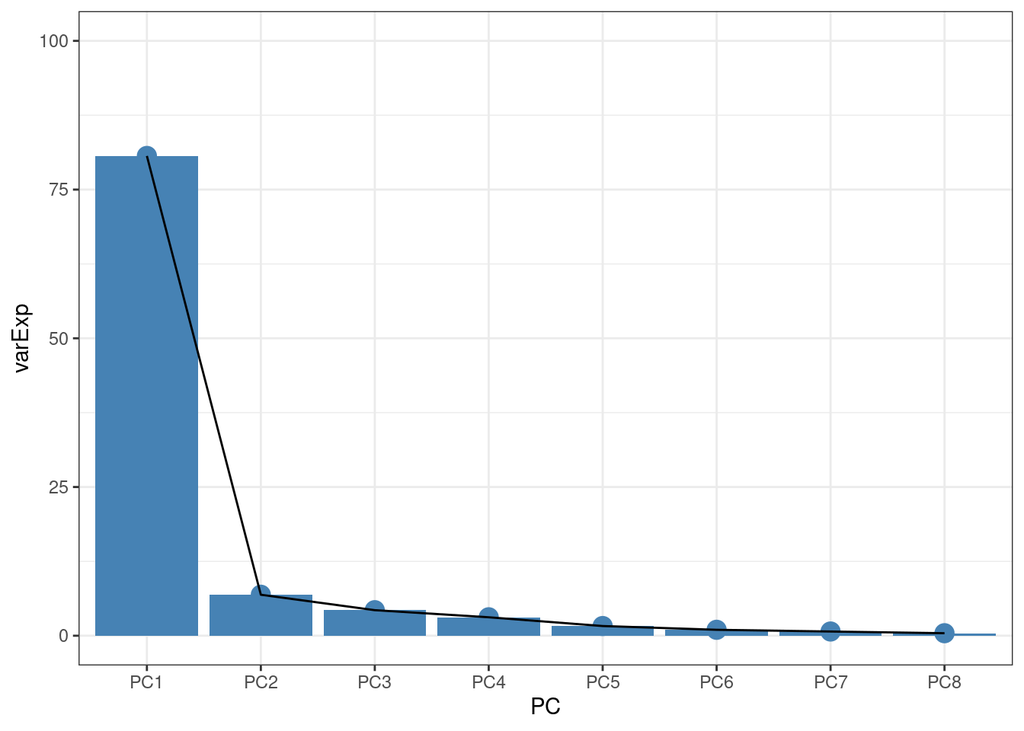

```r
# Run PCA
pcDat  <- prcomp(t(vsdSE), scale. = FALSE)

# Calculate explained variance
varExp <- (100*pcDat$sdev^2)/sum(pcDat$sdev^2)

# Store the explained variance of top 8 PCs
varExp_df <- data.frame(PC= paste0("PC",1:8),
                          varExp=varExp[1:8])

# Scree plot
varExp_df %>%
  ggplot(aes(x=PC,y=varExp, group=1)) +
  geom_point(colour="steelblue", size=4) +
  geom_col(fill="steelblue") +
  geom_line() +
  theme_bw() + ylim(c(0,100))
```

Let’s now plot the first and second principal components in 2-dimensions.

```r
plot_ly(as.data.frame(pcDat$x), x=~PC1, y=~PC2, color=meta$Condition, colors="Set1",
        type="scatter", mode="markers") %>%
  layout(title="PCA Plot")
```

[interactive chart not shown]

### Multi-dimensional scaling (MDS)

Multi-dimensional scaling is another dimensionality reduction which aims to best reconstruct pairwise distances between a set of points given a set of distances. Since in the case of RNA-seq we are given the data vectors directly rather than the distance matrices, methods must calculate the distance matrix first upon which the MDS algorithm is then performed. PCA is used in the process to produce a reduced dimensionality projection from the similarities.

Here, we use limma (Ritchie et al. 2015) to calculate the MDS and use plotly to visualise the pairwise distances in 3-dimensions.

```r
mds <- limma::plotMDS(vsdSE, plot=FALSE)
mdsOut <- mds$eigen.vectors[,1:3]
colnames(mdsOut) <- c("Leading logFC dim1", "Leading logFC dim2",
                      "Leading logFC dim3")
toPlot <- cbind(meta %>% rownames_to_column("Sample"), mdsOut)
plot_ly(toPlot, x=~`Leading logFC dim1`, y=~`Leading logFC dim2`, z=~`Leading logFC dim3`, color=~Condition, colors="Set1", type='scatter3d', mode='markers+text', text=~Sample, textposition = "top right") %>%
  plotly::layout(title="Classical MDS", scene=list(xaxis=list(title = 'Leading logFC dim1'), yaxis = list(title = 'Leading logFC dim2'), zaxis = list(title = 'Leading logFC dim3')))
```

[interactive chart not shown]

**PCA vs MDS**

The following image and linked StackedOverflow post explains well the difference between the two methods.

[figure not shown]

### Exercise #2

1. How many genes are used by the function `plotMDS` as inputs. What kind of genes are these?
2. Change the above function call so that all genes in the count matrix are used as input.

**Solutions**

1. By default, the top 500 genes are used.
2. We must change the `top` argument in order to include all necessary genes.

   ```r
   mds <- limma::plotMDS(vsdSE, top=nrow(vsdSE), plot=FALSE)
   ```

## Correlation Plots

We can also quantify the similarity between samples using correlations. This involves simply computing pairwise correlations between samples using the gene count vectors of each samples as inputs. The following methods this method as a basis.

### By-Sample Dendogram and Correlations

We can use hierarchical clustering using the pearson correlations as inputs. This will group samples together in a hierarchical fashion in a tree-like structure.

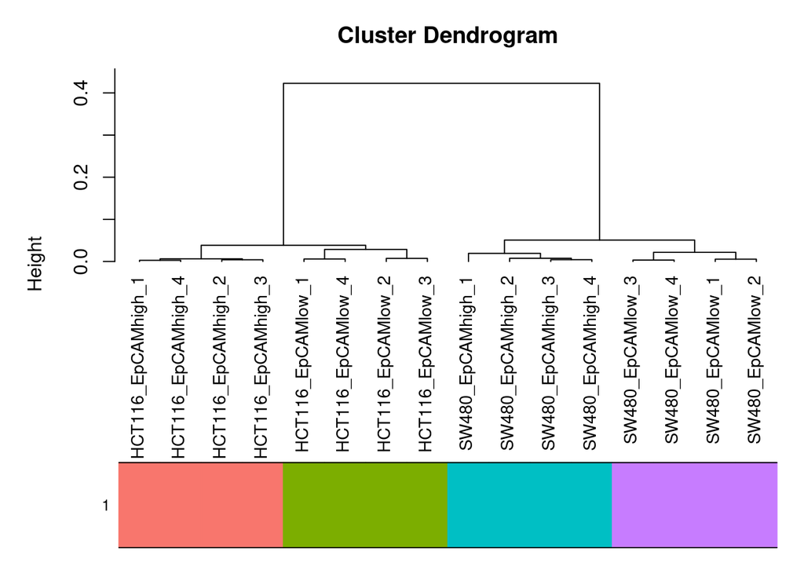

```r
d <- as.dist(1-cor(vsdSE, use="complete.obs"))   # calculate the pairwise correlations
hc <- hclust(d, method="ward.D2")  # run the clustering algorithm
WGCNA::plotDendroAndColors(hc, sampleColours, autoColorHeight=TRUE, hang = -0.1)
```

### Correlation Heatmap

Similarly, we can call `pheatmap` on the correlations to easily visualize the similarity between samples within and across conditions.

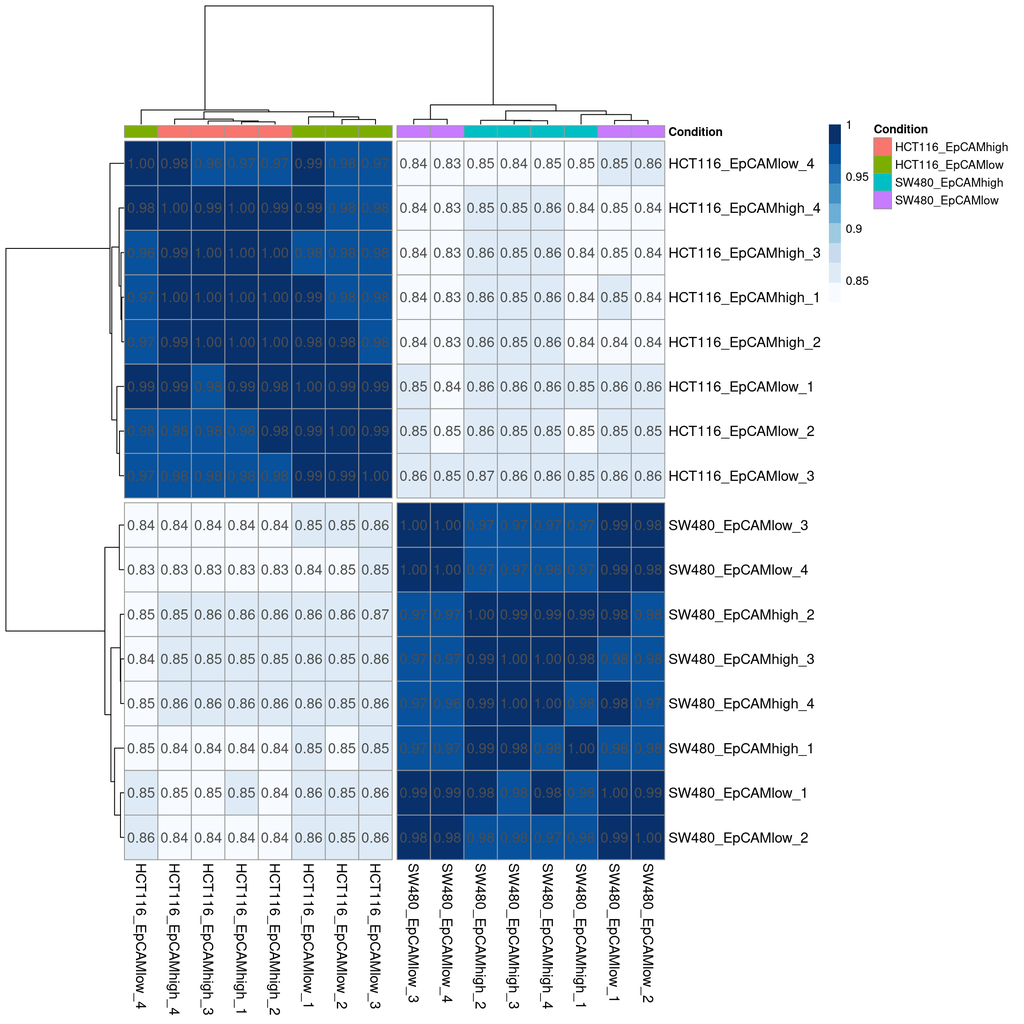

```r
# Pearson correlation plot
pheatmap(
  mat               = cor(vsdSE, use="complete.obs"),
  treeheight_row    = 100,
  treeheight_col    = 100,
  cutree_rows       = 2,
  cutree_cols       = 2,
  silent            = F,
  annotation_col    = meta,
  annotation_colors = list(Condition = conditionColours),
  color             = brewer.pal(n = 9, name = "Blues"),
  fontsize_row      = 12,
  fontsize_col      = 12,
  display_numbers   = TRUE,
  fontsize_number   = 12)
```

### Top 2’000 Variable Genes Heatmap

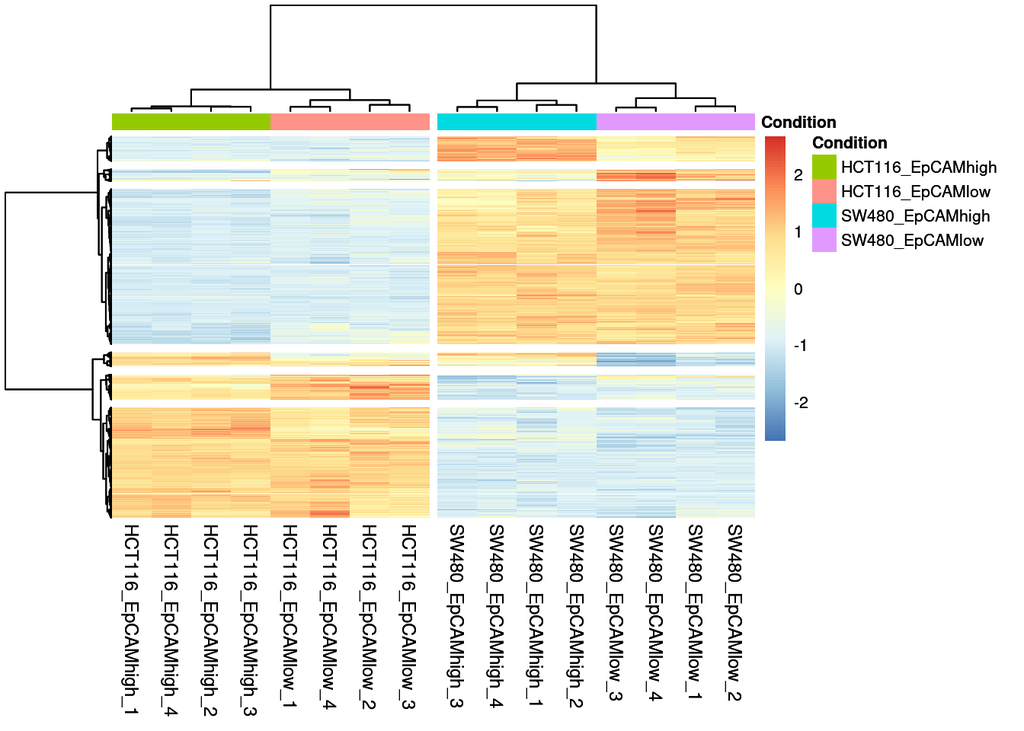

```r
# First, we center the matrix
vsdSECentered <- sweep(vsdSE, 1, rowMeans(vsdSE))
# Identify high variance features
topGenes <- rownames(vsdSE)[head(order(rowSds(vsdSE, na.rm=TRUE),
                                            decreasing = TRUE), 2000)]

countsToPlot <- vsdSECentered[topGenes,]

# Clustering of high variance features
hmObj <- pheatmap(countsToPlot,
         clustering_method="ward.D2",
         scale = "row", cluster_rows = TRUE,
         cluster_cols = TRUE, show_rownames = FALSE,
         cutree_rows = 6, cutree_cols = 2,
         treeheight_row = 50, treeheight_col = 50,
         annotation_col = meta,
         fontsize_row = 8, fontsize_col = 9,
         annotation_legend = TRUE,
         fontsize=8)
hmObj
```

## References

Love, Michael I., Wolfgang Huber, and Simon Anders. 2014. “Moderated Estimation of Fold Change and Dispersion for RNA-Seq Data with DESeq2” 15: 550. https://doi.org/10.1186/s13059-014-0550-8.

Ritchie, Matthew E, Belinda Phipson, Di Wu, Yifang Hu, Charity W Law, Wei Shi, and Gordon K Smyth. 2015. “Limma Powers Differential Expression Analyses for RNA-Sequencing and Microarray Studies” 43: e47. https://doi.org/10.1093/nar/gkv007.